# Measuring Race at Eight Geographic Scales, 2020

What the 2020 census says about race, at eight scales, and why only the smallest one describes anyone

Democracy’s Data

Last updated September 13, 2026 at 10:53a EDT

Eight Mile Road runs east and west along the northern city limit of Detroit. South of it is the city. North of it are the suburbs — Ferndale, Warren, Eastpointe. In 2002 the film *8 Mile* took its title from that road, because of what the road separates: the mostly Black city on one side, the largely White suburbs on the other.

The 2020 census can say how literally true that is. In the last 500 meters inside the city, the population is 90.7% Black. In the first 500 meters outside it, 53.5%. That is a fall of 37.2 points across one road.

Now the claim you have heard. The United States is more diverse than ever, and the 2020 census was reported everywhere in roughly those words. As a description of the whole country, the claim is true. But nobody lives in the whole country. So turn the claim into a question: **what is the racial makeup of your neighborhood — and does the answer depend on how big you draw “neighborhood”?**

## The test

Every number here comes out of one file, collected by the Census Bureau in the 2020 count and published as the [2020 Census Redistricting Data (P.L. 94-171) Summary File](https://www2.census.gov/programs-surveys/decennial/2020/data/01-Redistricting_File--PL_94-171/). Anyone can download it from that address, with no account or key; the copy used here is from 2026-08-11. It records the 331,449,281 people counted in the fifty states and the District of Columbia on 1 April 2020, and sorts each one into exactly one of 8 race-and-ethnicity categories. The decennial census chapter is the biography of that count — who is in it, who made it, and why. This brief borrows the file for one experiment.

The experiment holds everything fixed except one thing: same people, same categories, only the size of the unit the average is computed over changes.

The file publishes the same counts at every level of census geography: the nation, the 4 regions the Bureau groups states into (Northeast, Midwest, South and West), the 9 divisions those regions are split into, and 51 states with the District of Columbia. Below those sit 3,143 counties, 84,414 census tracts, 239,780 block groups and 8,132,968 blocks. A census tract is a Bureau-drawn unit of roughly 4,000 people, the closest official thing to a neighborhood; a block group is a cluster of blocks inside a tract, usually a few hundred to a few thousand people; a block is a city block. That is eight scales, and the same 331,449,281 people are added up at each one.

One measure is computed at every rung: the multigroup entropy index, a standard segregation measure, reported here as a diversity score from 0 to 100.[^1] The score asks how evenly a unit’s people are spread across the eight categories. A score of 0 means everyone in the unit is in one category; 100 means the eight categories are perfectly even; a unit that is mostly one group with a scattering of others lands somewhere low in between. The whole country, at 57.8% White, 18.7% Hispanic, 12.1% Black and the rest spread across five smaller categories, scores 60.4. At every rung below the nation the score is worked out for each unit on its own and then averaged over people, so a tract with twice the residents counts twice as much: the result is the score of the unit the average American lives in.

Why this source, of all sources? The question needs every box filled from the same records, and needs the smallest box to be genuinely small. The decennial census counts everyone rather than sampling, and this file reaches down to individual blocks. The usual alternative, the American Community Survey, stops at the block group. At small sizes its margin of error, the stated range for how far off an estimate could be, is often as large as the estimate itself. For a question about scale there is no second source.

## The data

Congress ordered this file into existence. Public Law 94-171, passed in 1975, requires the Bureau to hand every state small-area counts within a year of Census Day, so that legislative districts can be redrawn on time.[^2] Nobody built it to answer a question about neighborhoods, which is exactly why it can be asked one.

It does not arrive as a table, and it does not arrive in one piece. The Bureau publishes one archive per state and no national block file, so the ladder is assembled from 51 state files plus the Bureau’s national summary. The columns inside carry no names of their own; which column holds which count is set out in the technical documentation the Bureau publishes alongside the files.

Three decisions shape the tables below. Every geographic identifier is kept as text, so a state code stays `"01"` rather than becoming `1`. Puerto Rico is left out, because the Bureau publishes a file for it but does not include it in the national total. And the tables were accepted only once the eight categories accounted for the whole population at every level of every state, and each state’s blocks added up to the state.

The tables this brief hands over carry one row per unit. Each row holds `total` and the eight categories (`hispanic`, `nh_white`, `nh_black`, `nh_asian`, `nh_two`, `nh_aian`, `nh_sor`, `nh_nhpi`), which cover every person exactly once. The `entropy` column is computed here, and the Wayne County tables add `largest` and `largest_pct`, the biggest group in the unit and its share. The county and state tables also carry each race counted two ways, `white_alone` beside `white_any`; the `census-race` lab takes that pair of official counts apart. Here the eight non-overlapping categories do the work, because a mixing measure needs categories every person falls into exactly once.

One more fact about the boxes hangs over every number below: the categories are not the Bureau’s. The Office of Management and Budget sets them for every federal agency, rewrote them in 1997 to allow more than one mark, and again in 2024.[^3] They are a federal decision, not a fact about people.

> **Before the first figure, commit to a number.** On the 0-to-100 mixing scale, the whole United States scores 60.4. Write down the score you expect for the census tract the average American lives in. Higher than the country, or lower — and by a little, or by a lot?

## What it says about democracy

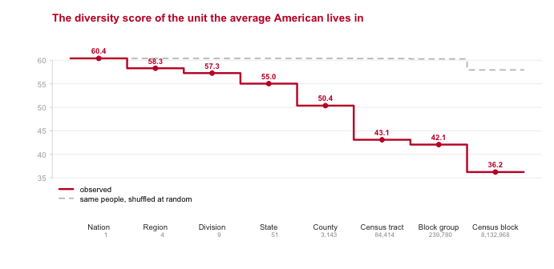

**Figure 1. Eight rungs, the same 331,449,281 people, one measure.** Each step is the diversity score of the unit the average American lives in at that scale. The line is a staircase rather than a slope, because the rungs are eight separate calculations, not points on a path. The dashed line is the control: the identical people shuffled at random into units of the identical sizes.

The score falls from 60.4 for the country to 55.0 for states, 50.4 for counties, 43.1 for tracts and 36.2 for blocks. Nobody moves. Only the box shrinks.

The control line is what makes that fall meaningful. Finer units always look more segregated, even under random assignment, because small units are noisy. Shuffled, the score stays flat at the national value all the way down to the block-group rung, so the observed fall is people rather than arithmetic. Only at the block rung, where units hold a few dozen people, does randomness begin to produce apparent sorting on its own.

Said without any index: **33.9% of Americans live in a census tract where at least four residents in five are in the same category.** 13.1% live in one where at least nine in ten are. Only 17.1% live in a tract whose largest group is under half. The country’s headline diversity is real, and it is assembled out of neighborhoods that are mostly not diverse at all.

One county shows how the averaging works. **Wayne County, Michigan** holds 1,793,561 people, contains Detroit, and has no majority group at all: 47.8% White, 37.3% Black, 6.6% Hispanic and 3.6% Asian. Its diversity score of 57.2 puts it in the most diverse 6.2% of all 3,143 American counties. From the county row alone, you would call it one of the more integrated places in the country.

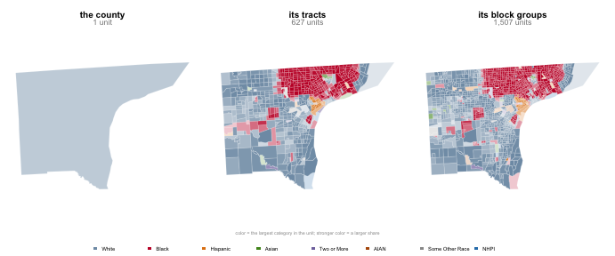

**Figure 2. Wayne County, Michigan, at three scales.** The same 1,793,561 people and the same ground in all three panels; only the size of the unit changes. Color is the largest category in each unit, and stronger color is a larger share, so the deep colors are the near-uniform units.

Split into 627 tracts, the no-majority county becomes two counties: 307 tracts where the largest group is White and 279 where it is Black, with a visible boundary between them and very little in between. **The median Wayne County tract — the middle one, with half the county’s tracts more uniform than it and half less — is 81.6% a single category.** 201 tracts are at least 80% Black and 125 are at least 80% White, and together those tracts hold 51.8% of the county’s population. Both sentences describe Wayne County in 2020, the no-majority county and the county of four-fifths neighborhoods — and only the second is about anybody’s street.

The boundary in the middle panel is the road this brief opened on. It is Eight Mile Road, Detroit’s northern city limit, and it fell out of a map colored by largest group; nobody drew it in. Figure 3 walks up to it. The corridor was selected geographically, from the Bureau’s own published city boundary, before anyone looked at who lived in it: every block within 2.5 km of the line, 5,445 blocks holding 299,535 people.

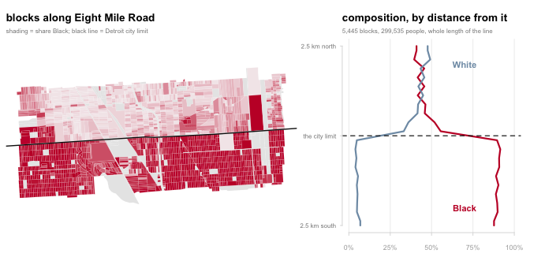

**Figure 3. A line you can stand on.** Left: every census block in a 12 km window of Detroit’s northern boundary, shaded by the share of residents who are non-Hispanic Black; the heavy line is the city limit as the Bureau publishes it. Right: composition against distance from that boundary, in 250-meter bands, sharing the map’s vertical axis — so the step in the profile and the line on the map are the same object seen twice.

South of the line the corridor is 89.9% Black, and it is that at every distance. North of it, 45.2%. **Between the last 500 meters inside the city and the first 500 meters outside it, the Black share falls from 90.7% to 53.5%: 37.2 points across one road.**

The shape matters as much as the size. The profile is not a gradient. It is flat, then a step, then flat again, so composition does not fade with distance from the city the way something spreading outward would. Whatever produced this pattern operated on the line itself — on which side of a municipal border a house sits. Redlining (the 1930s federal appraisal maps that marked Black neighborhoods as unfit for mortgage lending), restrictive covenants (clauses in property deeds forbidding sale to Black buyers) and municipal incorporation (the drawing of a suburb’s legal boundary) all work that way,[^4] and the `redlining` lab follows one of them from a 1939 appraisal form to the ground.

Now the payoff, and it is administrative. Along this stretch, Eight Mile is not only the city limit but also the county line: Wayne County to the south, Macomb and Oakland to the north. The corridor spans 3 counties, and **a boundary this sharp, and this widely known, appears in no county statistic at all.** Each county publishes one row in which its own side of the step has already been averaged together with ground far away from it. The line is not concealed and it is not disputed. It is invisible by arithmetic — and invisible in exactly the numbers that reporting, funding formulas and most social science reach for first.

That is what the ladder says about democracy. Representation, school funding and Voting Rights Act claims are all computed over some unit, and the choice of unit changes the answer. The 3,143 counties of the United States are 3,143 averages; every one of them has boundaries; and there is no reason to expect those boundaries to be demographically quiet. Segregation is real and sharp at ground level, and the county row cannot see it.

## What this brief cannot tell you

**Whether any of this survives the next set of categories.** Every score here is computed over eight boxes that the 2024 revision of the federal standard (89 FR 22182) is due to replace. Race and Hispanic origin become one question, Middle Eastern or North African is added, and the minimum list grows from 6 race categories to 7. Merge two categories and the diversity score falls; split one and it rises; nobody has to move.

**How the country changed since 2010.** Between the two censuses the Bureau redesigned how write-in answers were captured and coded. Its own analysts attribute much of the resulting jump to those improvements rather than to demographic change.[^5] In the same pair of files, the count of people who are White alone falls 8.6% while the count who are White in any combination rises 1.9%. This data will not support a clean time series of race.

**Exact block counts.** To protect respondents, the 2020 census added deliberate statistical noise before publication, a method the Bureau calls differential privacy: state totals were held exact, but block-level counts were altered, and the noise is proportionally largest where units are smallest.[^6] The control in Figure 1 shows that block-level sorting is overwhelmingly real; no single block count here should be treated as exact.

**Anything about voters.** Everything counted here is total population, children and non-citizens included. Voting-age population sits in the same file and gives different numbers.

**Why anybody lives where they live.** A step at a municipal boundary is strong evidence that something operated on the boundary; nothing in this file says what. And a companion lab, `areal-units`, shows how far a statistic can move from redrawing units alone — the reason Figure 1 needed its shuffled control.

## What you should have learned

- The same 331,449,281 people score 60.4 on the mixing scale as one country and 43.1 as a set of census tracts. The unit is part of every demographic answer.
- The fall down the ladder is people, not arithmetic: shuffled at random into units of the same sizes, the score stays flat until the block rung.
- A county with no majority group can still be a county of near-uniform neighborhoods. The median Wayne County tract is 81.6% one category.
- The sharpest boundaries can sit on administrative lines and vanish from those units’ own statistics: 37.2 points across Eight Mile Road, averaged away in all 3 counties it separates.
- The categories under every number are a federal decision, rewritten in 1997 and again in 2024, and every score in this brief changes when they do.

## Extensions

- `ladder.csv` measures the same country at all eight scales. Read `diversity` and `pct_single_group` down the rungs. At which scale does America stop looking mixed and start looking sorted?
- `counties.csv` carries both `white_alone` and `white_any` for every county. Take the difference and sort it. Where does that one qualifier do the most work?
- `wayne_tracts.csv` gives each tract a `largest` group and its `largest_pct`. Count the tracts where one group is more than nine residents in ten.
- `wayne_transect.csv` records each block’s `side` of Eight Mile. Group by it and compare summed `nh_black` against summed `total`.
- `states.csv` has an `entropy` column. Sort it. Which states sit at the two ends, and does the answer match the map in your head?
- Stretch: the archive in Sources holds one file per state. Download your own state’s blocks, find a boundary you know, and walk it the way Figure 3 walks Eight Mile Road.
- Stretch: put `decades.csv` beside `standards.csv` and decide, category by category, how much of the 2010-to-2020 change could be people and how much is the question changing under them.

## Sources

**Data**

- U.S. Census Bureau, *2020 Census Redistricting Data (P.L. 94-171) Summary File*, legacy format — Tables P1 and P2, for the nation, regions, divisions, 51 states and the District of Columbia, 3,143 counties, 84,414 tracts, 239,780 block groups and 8,132,968 blocks. Downloaded 2026-08-11; no key or account needed. https://www2.census.gov/programs-surveys/decennial/2020/data/01-Redistricting_File--PL_94-171/
- U.S. Census Bureau, *2010 Census Redistricting Data (P.L. 94-171) Summary File*, national file, read for the decade table handed over below. https://www2.census.gov/census_2010/redistricting_file--pl_94-171/National/
- U.S. Census Bureau, *TIGER/Line Shapefiles*, 2020 — the county, tract, block group, block and place boundaries behind Figures 2 and 3. https://www2.census.gov/geo/tiger/TIGER2020/

**The standards and the measure**

- Office of Management and Budget, *Statistical Policy Directive No. 15*, 12 May 1977; revised 30 October 1997 (62 FR 58782) and 29 March 2024 (89 FR 22182). The three documents that set the categories. https://www.federalregister.gov/documents/1997/10/30/97-28653/revisions-to-the-standards-for-the-classification-of-federal-data-on-race-and-ethnicity and https://www.federalregister.gov/documents/2024/03/29/2024-06469/revisions-to-ombs-statistical-policy-directive-no-15-standards-for-maintaining-collecting-and-presenting
- Public Law 94-171, 89 Stat. 1023 (1975), now 13 U.S.C. § 141(c) — the statute that orders the file. https://www.law.cornell.edu/uscode/text/13/141
- Nicholas Jones, Rachel Marks, Roberto Ramirez and Merarys Ríos-Vargas, “2020 Census Illuminates Racial and Ethnic Composition of the Country,” U.S. Census Bureau, 12 August 2021 — the Bureau’s own account of the 2010-to-2020 processing changes. https://www.census.gov/library/stories/2021/08/improved-race-ethnicity-measures-reveal-united-states-population-much-more-multiracial.html
- U.S. Census Bureau, “Disclosure Avoidance and the 2020 Census” — the noise added to block counts before publication. https://www.census.gov/programs-surveys/decennial-census/decade/2020/planning-management/process/disclosure-avoidance.html
- Theil, H. (1972). *Statistical Decomposition Analysis.* Amsterdam: North-Holland. Reardon, S. F. and Firebaugh, G. (2002). “Measures of Multigroup Segregation.” *Sociological Methodology* 32(1): 33–67. The diversity measure, and why entropy rather than a two-group index when there are eight categories. https://cepa.stanford.edu/content/measures-multigroup-segregation
- Sugrue, T. J. (1996). *The Origins of the Urban Crisis: Race and Inequality in Postwar Detroit.* Princeton: Princeton University Press. The history of redlining, covenants and municipal boundaries in the city Figure 3 walks. https://press.princeton.edu/books/paperback/9780691162553/the-origins-of-the-urban-crisis

**The data itself**

Every figure above is drawn from these tables. They are plain CSV, they open in a spreadsheet, and they are yours to take further.

`categories.csv`, `counties.csv`, `decades.csv`, `eightmile_profile.csv`, `ladder.csv`, `metros.csv`, `nation.csv`, `regions.csv`, `standards.csv`, `states.csv`, `tract_dist.csv`, `tract_largest.csv`, `us_divisions.csv`, `us_maplabels.csv`, `us_rings.csv`, `wayne_bg.csv`, `wayne_bg_rings.csv`, `wayne_block_rings.csv`, `wayne_detroit_rings.csv`, `wayne_outline.csv`, `wayne_tract_rings.csv`, `wayne_tracts.csv`, `wayne_transect.csv`

One more file is not data about the subject – it is how this chapter checked its own numbers: `facts.csv`, the individual numbers the text above quotes.

Rebuild this data yourself, with an AI assistant

```
I want to rebuild a public dataset from its original source, without any
starting files. Please do the following and show your work.

THE SOURCE. U.S. Census Bureau, 2020 Census Redistricting Data
(P.L. 94-171) Summary File, legacy format, keyless flat files:
- the national roll-up, one small zip:
  https://www2.census.gov/programs-surveys/decennial/2020/data/01-Redistricting_File--PL_94-171/National/us2020.npl.zip
  816,297 bytes, 2,832 geographic records -- the nation, its regions
  and divisions, the states and the metro areas, all in one file
- one zip per state in the same directory, for county-level rows,
  for example Michigan/mi2020.pl.zip
An honest warning about the second half: all 51 state files (50
states and DC) come to about 1.3 GB compressed. If you only want the
shape of the thing, download the national file plus one state and say
so. Each zip holds pipe-delimited files with no headers: a geographic
header, one row per geographic unit, and data segments joining it on
the LOGRECNO column. In the first segment, Table P1 (race) starts at
field 6 and Table P2 (Hispanic or Latino origin by race) at field 77.
Read codes as text. Puerto Rico has a file but is not in the national
total.

WHAT TO BUILD.
1. The national composition: total population, Hispanic or Latino,
   and each non-Hispanic race group, as counts and shares -- and each
   race both ways the Bureau publishes it, "alone" and "alone or in
   combination". The gap between those two readings is the point.
2. From whichever state files you downloaded, a county table of the
   same categories.

CHECK YOUR WORK. The copies this book used were downloaded in August
2026. If your rebuild matches them, you should find:
- a national population of 331,449,281
- 62,080,044 Hispanic or Latino -- 18.73%
- non-Hispanic white alone at 57.84%
- 2,832 geographic records in the national file
These are final 2020 census files; they will not change until the
2030 census publishes successors.
```

[^1]: The index is Theil’s entropy, brought to segregation in Henri Theil, *Statistical Decomposition Analysis* (Amsterdam: North-Holland, 1972), and extended to more than two groups in Sean F. Reardon and Glenn Firebaugh, “Measures of Multigroup Segregation,” *Sociological Methodology* 32, no. 1 (2002): 33–67, https://cepa.stanford.edu/content/measures-multigroup-segregation.
[^2]: Public Law 94-171, 89 Stat. 1023 (1975), https://www.govinfo.gov/content/pkg/STATUTE-89/pdf/STATUTE-89-Pg1023.pdf, now 13 U.S.C. § 141(c), https://www.law.cornell.edu/uscode/text/13/141.
[^3]: The 1997 revision is at 62 FR 58782, https://www.federalregister.gov/documents/1997/10/30/97-28653/revisions-to-the-standards-for-the-classification-of-federal-data-on-race-and-ethnicity; the 2024 revision at 89 FR 22182, https://www.federalregister.gov/documents/2024/03/29/2024-06469/revisions-to-ombs-statistical-policy-directive-no-15-standards-for-maintaining-collecting-and-presenting. “FR” is the *Federal Register*, the government’s daily record of rules and notices, cited by volume and page.
[^4]: The history of all three in Detroit is the subject of Thomas J. Sugrue, *The Origins of the Urban Crisis: Race and Inequality in Postwar Detroit* (Princeton: Princeton University Press, 1996), https://press.princeton.edu/books/paperback/9780691162553/the-origins-of-the-urban-crisis.
[^5]: Nicholas Jones, Rachel Marks, Roberto Ramirez and Merarys Ríos-Vargas, “2020 Census Illuminates Racial and Ethnic Composition of the Country,” U.S. Census Bureau, 12 August 2021, https://www.census.gov/library/stories/2021/08/improved-race-ethnicity-measures-reveal-united-states-population-much-more-multiracial.html.
[^6]: U.S. Census Bureau, “Disclosure Avoidance and the 2020 Census,” https://www.census.gov/programs-surveys/decennial-census/decade/2020/planning-management/process/disclosure-avoidance.html.